# Homework 2

Angela Zhao

# Image Compression Function

The following function performs image compression using PCA.

```r
image_compression <- function(x, k) {

  # Cross-product matrix
  V <- t(x) %*% x

  # Eigendecomposition
  eig <- eigen(V)

  # Eigenvectors
  U <- eig$vectors

  # Principal component scores
  Z <- x %*% U

  # Rank-k approximation
  x_k <- Z[, 1:k, drop = FALSE] %*%
    t(U[, 1:k, drop = FALSE])

  # Frobenius norm error
  error <- norm(x - x_k, type = "F")

  # Return both
  list(
    approximation = x_k,
    error = error
  )
}
```

# Image 1

## Original Image + First 10 PCA Approximations

The following plot shows the original image followed by the PCA approximations for $k=1,\ldots,10$.

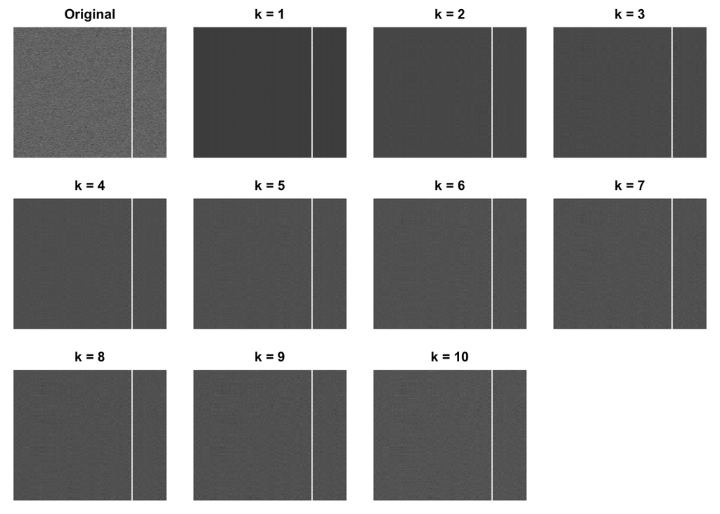

## Approximation Error vs. k

The following plot shows the approximation error for all possible values of $k$.

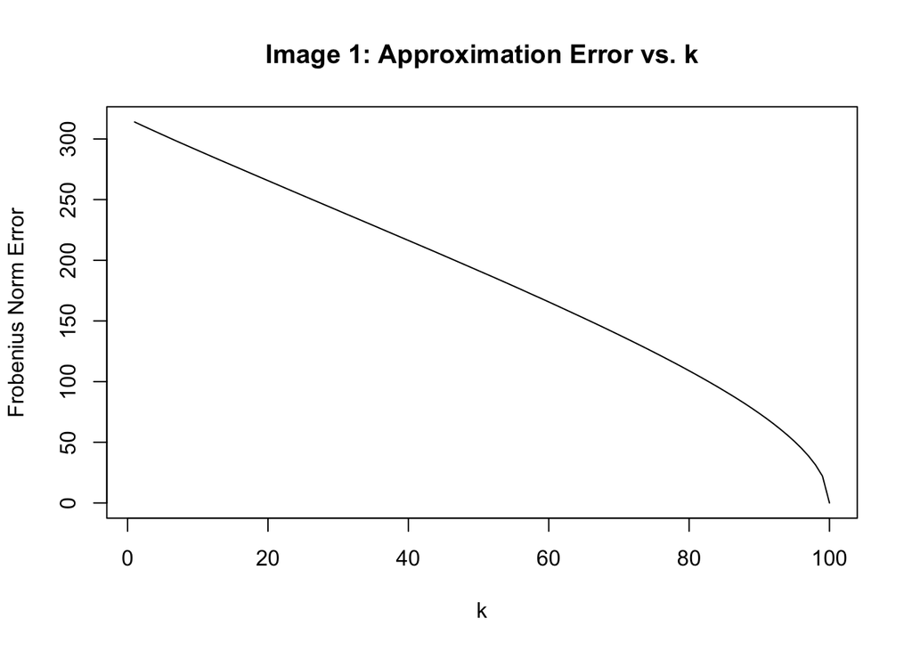

## First Eigenvector and First PC Score

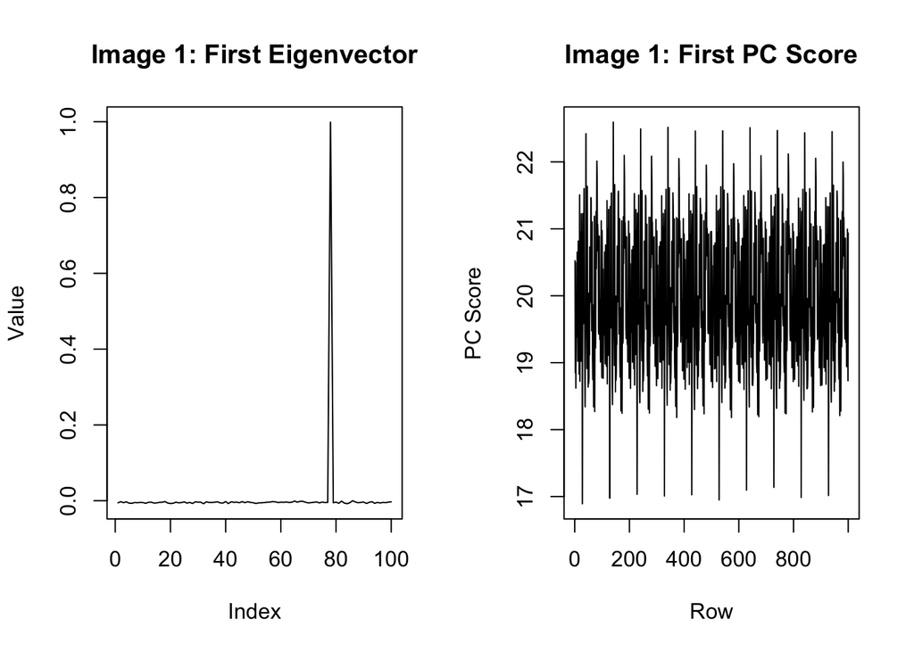

### Interpretation

The **first eigenvector** represents the direction of greatest variation in the data captured by PCA. For this image, there is a significant spike around column 80, which means that the first principal component is dominated by the column around that index. The **first PC score** shows the values oscillating across all the rows. This means that the pattern is changing consistently across the rows of the image.

# Image 2

## Original Image + First 10 PCA Approximations

The following plot shows the original image followed by the PCA approximations for $k=1,\ldots,10$.

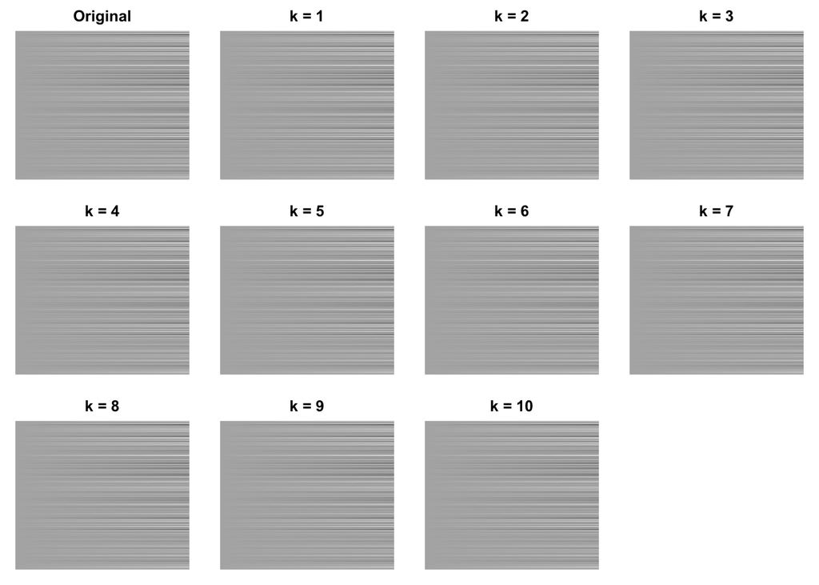

## Approximation Error vs. k

The following plot shows the approximation error for all possible values of $k$.

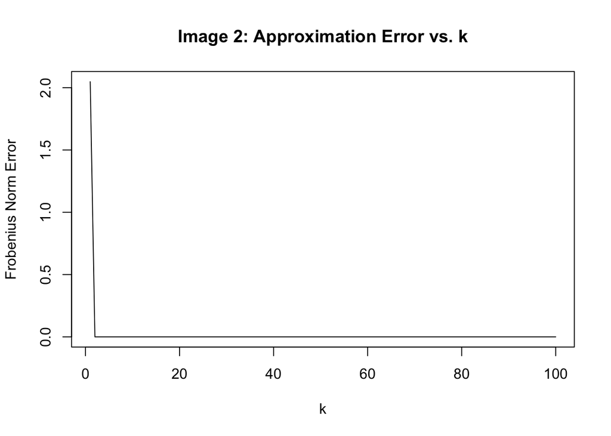

## First Eigenvector and First PC Score

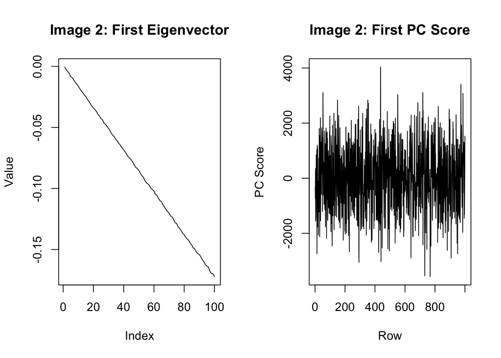

### Interpretation

The first eigenvector shows a roughly linear decrease across the columns, meaning that the columns contribute gradually to the main pattern captured by the first principal component. The first PC score oscillates across the rows, showing that this main pattern changes consistently throughout the image.

# Image 3

## Original Image + First 10 PCA Approximations

The following plot shows the original image followed by the PCA approximations for $k=1,\ldots,10$.

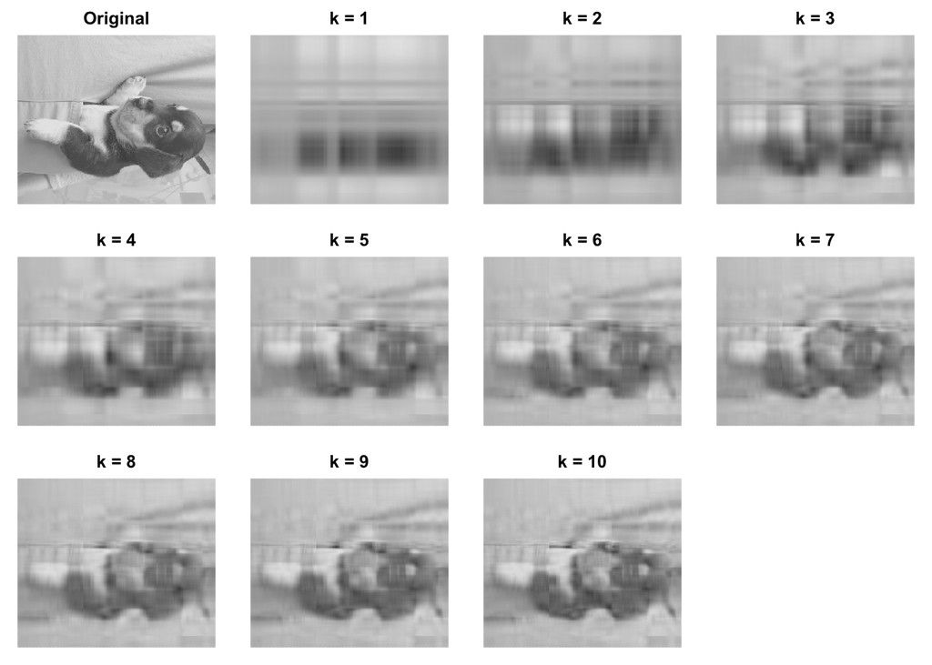

## Approximation Error vs. k

The following plot shows the approximation error for all possible values of $k$.

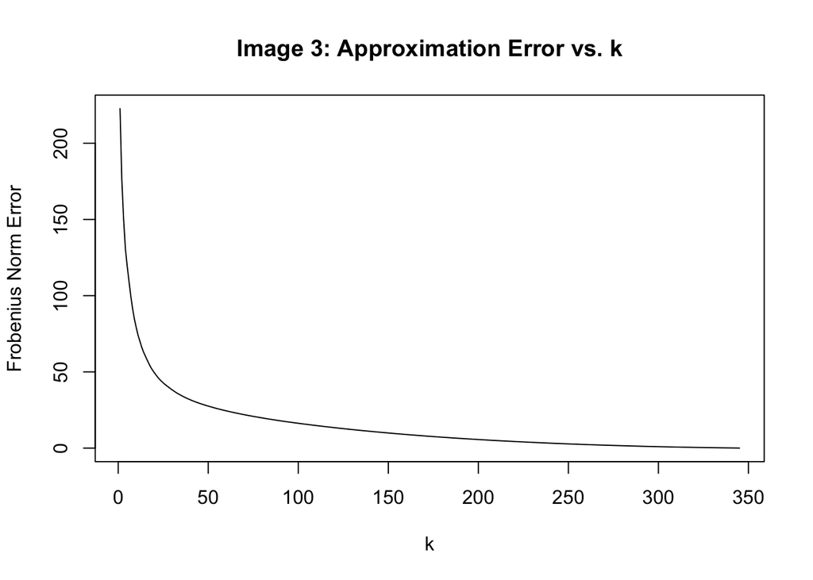

## First Eigenvector and First PC Score

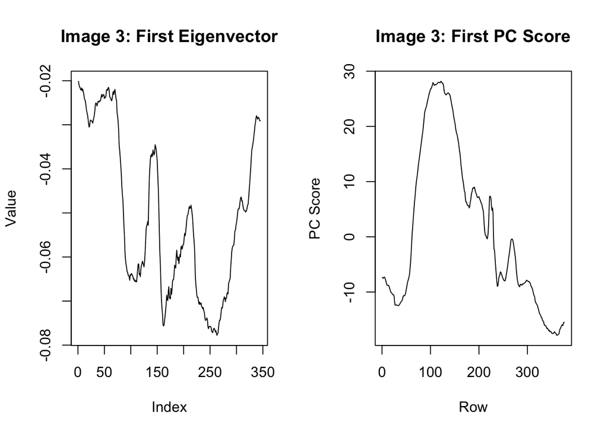

### Sufficiently Good Approximation

The approximation error drops very quickly as $k$ increases up to around $k = 10$, and then the curve begins to flatten. This suggests that the first 10 principal components capture most of the important information in the image, while adding more components results in smaller improvements. Based on the error plot, I would consider $k = 10$ to be a sufficient approximation. The plots show the image becoming clearer around k = 8.

# Image 4

## Original Image + First 10 PCA Approximations

The following plot shows the original image followed by the PCA approximations for $k=1,\ldots,10$.

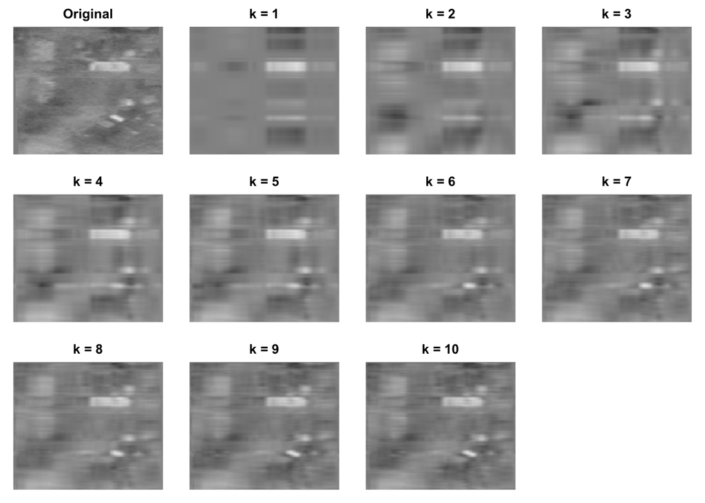

## Approximation Error vs. k

The following plot shows the approximation error for all possible values of $k$.

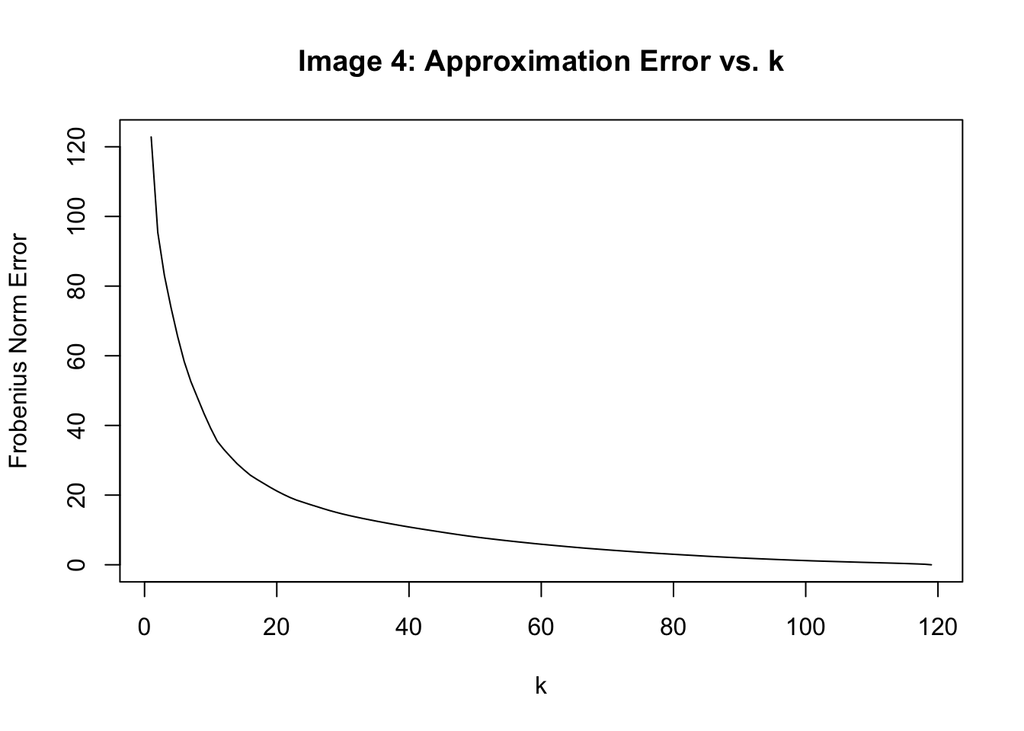

## First Eigenvector and First PC Score

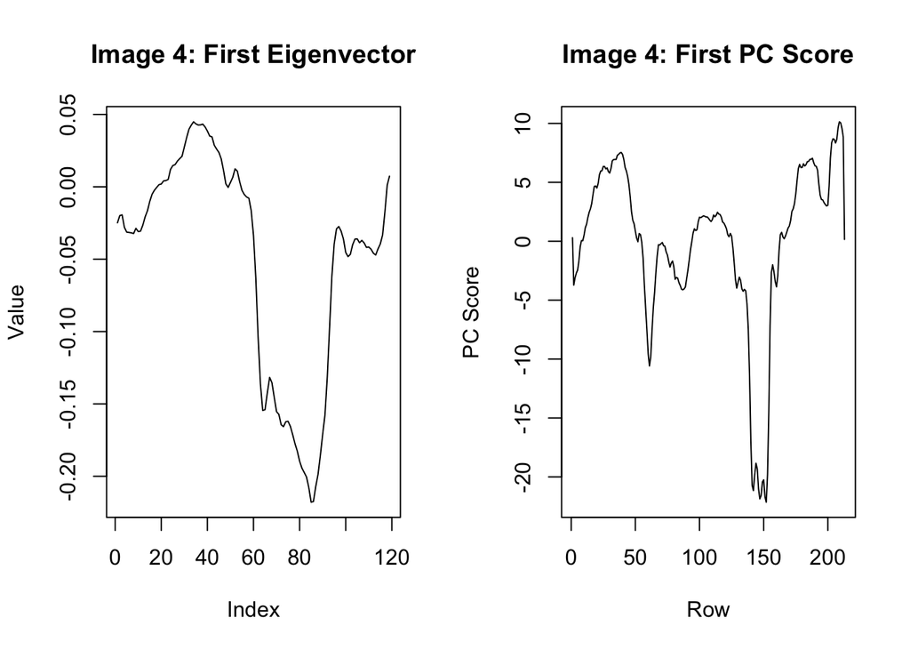

### Interpretation

The first eigenvector has a sharp dip around index 80, suggesting that a group of columns around this location contributes differently to the main pattern captured by the first principal component. The first PC score has a similar downward dip around row 150, indicating that the strength or direction of this main pattern changes noticeably around that part of the image. Together, these graphs suggest that the main pattern identified by PCA is associated with a particular region of the image rather than being distributed uniformly across all columns and rows.

### Sufficiently Good Approximation

Similarly to image 3, the approximation error drops quickly as $k$ increases up to around $k = 10 or k = 15$, and then the curve begins to flatten. This suggests that the first 10 principal components capture most of the important information in the image, while adding more components results in smaller improvements. Based on the error plot, I would consider $k = 10$ to be a sufficient approximation. The image also starts getting clearer around then, which provides support for this point.